# IODS course project

## Standardising the data

I’ll standardise the data set by subtracting the column means from the corresponding columns and dividing the difference by the standard deviation.

```r
boston_scaled <- scale(Boston)
```

Let’s see how the variables changed:

```r
summary(boston_scaled)
```

```
##       crim                 zn               indus              chas
##  Min.   :-0.419367   Min.   :-0.48724   Min.   :-1.5563   Min.   :-0.2723
##  1st Qu.:-0.410563   1st Qu.:-0.48724   1st Qu.:-0.8668   1st Qu.:-0.2723
##  Median :-0.390280   Median :-0.48724   Median :-0.2109   Median :-0.2723
##  Mean   : 0.000000   Mean   : 0.00000   Mean   : 0.0000   Mean   : 0.0000
##  3rd Qu.: 0.007389   3rd Qu.: 0.04872   3rd Qu.: 1.0150   3rd Qu.:-0.2723
##  Max.   : 9.924110   Max.   : 3.80047   Max.   : 2.4202   Max.   : 3.6648
##       nox                rm               age               dis
##  Min.   :-1.4644   Min.   :-3.8764   Min.   :-2.3331   Min.   :-1.2658
##  1st Qu.:-0.9121   1st Qu.:-0.5681   1st Qu.:-0.8366   1st Qu.:-0.8049
##  Median :-0.1441   Median :-0.1084   Median : 0.3171   Median :-0.2790
##  Mean   : 0.0000   Mean   : 0.0000   Mean   : 0.0000   Mean   : 0.0000
##  3rd Qu.: 0.5981   3rd Qu.: 0.4823   3rd Qu.: 0.9059   3rd Qu.: 0.6617
##  Max.   : 2.7296   Max.   : 3.5515   Max.   : 1.1164   Max.   : 3.9566
##       rad               tax             ptratio            black
##  Min.   :-0.9819   Min.   :-1.3127   Min.   :-2.7047   Min.   :-3.9033
##  1st Qu.:-0.6373   1st Qu.:-0.7668   1st Qu.:-0.4876   1st Qu.: 0.2049
##  Median :-0.5225   Median :-0.4642   Median : 0.2746   Median : 0.3808
##  Mean   : 0.0000   Mean   : 0.0000   Mean   : 0.0000   Mean   : 0.0000
##  3rd Qu.: 1.6596   3rd Qu.: 1.5294   3rd Qu.: 0.8058   3rd Qu.: 0.4332
##  Max.   : 1.6596   Max.   : 1.7964   Max.   : 1.6372   Max.   : 0.4406
##      lstat              medv
##  Min.   :-1.5296   Min.   :-1.9063
##  1st Qu.:-0.7986   1st Qu.:-0.5989
##  Median :-0.1811   Median :-0.1449
##  Mean   : 0.0000   Mean   : 0.0000
##  3rd Qu.: 0.6024   3rd Qu.: 0.2683
##  Max.   : 3.5453   Max.   : 2.9865
```

Now the mean of each variable is 0. The standardised values show how many standard deviations the observation differs from the mean.

Here I’m creating a categorical variable from the continuous variable of the crime rate. I’m also removing the original crime rate variable from the data set and adding the new categorical crime rate variable to it.

```r
boston_scaled <- as.data.frame(boston_scaled)
bins <- quantile(boston_scaled$crim)
crime <- cut(boston_scaled$crim, breaks = bins, include.lowest = TRUE, label = c("low", "med_low", "med_high", "high"))
boston_scaled <- dplyr::select(boston_scaled, -crim)
boston_scaled <- data.frame(boston_scaled, crime)
```

## Creating a training set and a test set

```r
n <- nrow(boston_scaled)
ind <- sample(n,  size = n * 0.8)
train <- boston_scaled[ind,]
test <- boston_scaled[-ind,]
```

## Linear discriminant analysis

Then it’s time to fit the linear discriminant analysis on the training set. I’m using the categorical crime rate as the target variable and all the other variables as predictors.

```r
lda.fit <- lda(crime ~ ., data = train)
```

This is how the LDA biplot looks like:

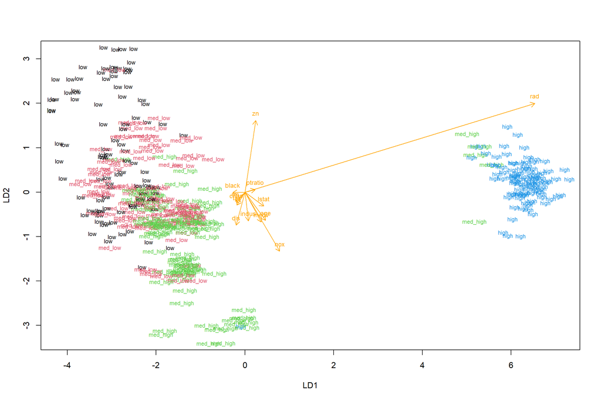

```r
lda.arrows <- function(x, myscale = 1, arrow_heads = 0.1, color = "orange", tex = 0.75, choices = c(1,2)){
  heads <- coef(x)
  arrows(x0 = 0, y0 = 0,
         x1 = myscale * heads[,choices[1]],
         y1 = myscale * heads[,choices[2]], col=color, length = arrow_heads)
  text(myscale * heads[,choices], labels = row.names(heads),
       cex = tex, col=color, pos=3)
}
classes <- as.numeric(train$crime)
plot(lda.fit, dimen = 2, col = classes, pch = classes)
lda.arrows(lda.fit, myscale = 2)
```

The biplot depicts observations classified by the different crime rates with different colours. The high crime rates form the most distinct cluster. The length of the arrows represents how strongly those variables contribute to the discrimination of the clusters. The index of accessibility to radial highways (rad) is clearly the most disriminating one.

## Predictions

Next, I’ll save the crime categories from the test set and remove the crime variable from it.

```r
correct_classes <- test$crime
test <- dplyr::select(test, -crime)
```

Now I’m going to use the LDA model based on the training data to predict the classes. I’ll also cross tabulate the results.

```r
lda.pred <- predict(lda.fit, newdata = test)
table(correct = correct_classes, predicted = lda.pred$class)
```

```
##           predicted
## correct    low med_low med_high high
##   low       17       9        2    0
##   med_low    3      16        5    0
##   med_high   0       8       16    1
##   high       0       0        0   25
```

From the table above, we can see that most of the cases are predicted correctly. The performance seems to be best for the high crime rate category, where almost all cases are predicted correctly. Lower crime rates have more incorrectly predicted cases. Both low and medium high crime rates are quite often incorrectly predicted as medium low.

## K-means

To calculate the distances between the observations, I’m going to reload and standardise the Boston data set.

```r
library(MASS)
data('Boston')
boston_scaled <- scale(Boston)
boston_scaled <- as.data.frame(boston_scaled)
```

Let’s look at the euclidean distances between the observations:

```r
dist_eu <- dist(boston_scaled)
summary(dist_eu)
```

```
##    Min. 1st Qu.  Median    Mean 3rd Qu.    Max.
##  0.1343  3.4625  4.8241  4.9111  6.1863 14.3970
```

I’ll run k-means clustering algorithm on the data set. To determine the optimal number of clusters, I’ll examine how the total within cluster sum of squares changes in relation to the number of clusters. I’ll limit the maximum number of clusters to 10.

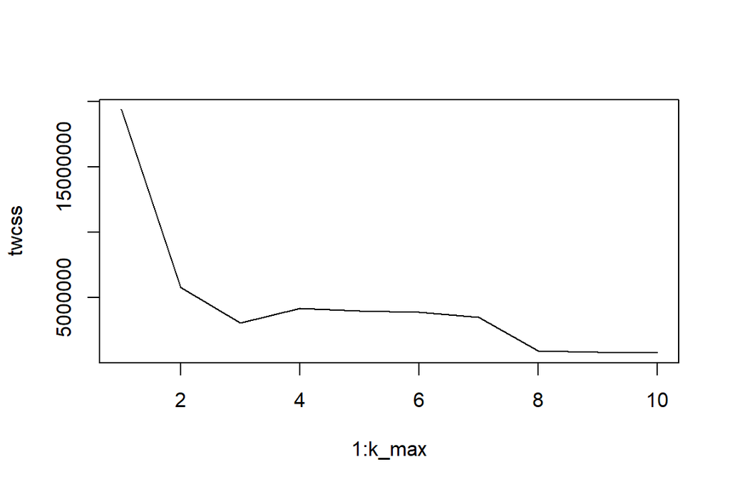

```r
km <-kmeans(boston_scaled, centers = 2)
set.seed(123)
k_max <- 10
twcss <- sapply(1:k_max, function(k){kmeans(Boston, k)$tot.withinss})
plot(x = 1:k_max, y = twcss, type = "l")
```

The largest change seems to be between one and two clusters. After that there are only smaller changes. Thus, two clusters seems to be appropriate. I’ll visualise the two clusters with a scatter plot matrix:

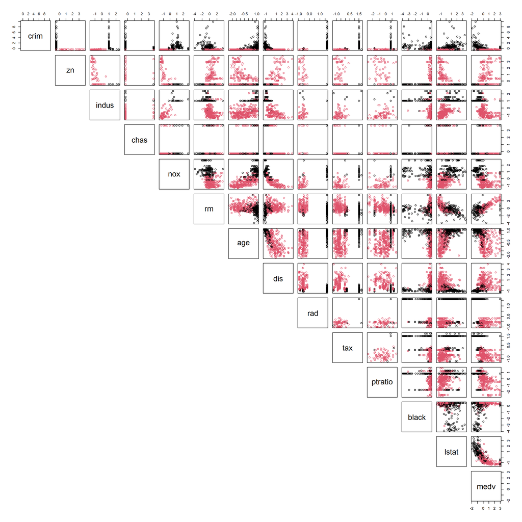

```r
pairs(boston_scaled, col = km$cluster, lower.panel = NULL)
```

In most of the scatter plots, the two clusters seem to be reasonably distinct. The cluster with higher crime rates also has, for example, smaller proportion of large residential land lots, more industrial areas, higher nitrogen oxide concentration, smaller distance to employment centres, better accessibility to radial highways, and larger pupil-teacher ratio.

```r
options(scipen = 999)
```

# Dimensionality reduction techniques

## Loading and inspecting the data

This weeks data deals with human development indicators and the data sets originate from the United Nations Development Programme. You can find more information about the data on their web page: http://hdr.undp.org/en/content/human-development-index-hdi.

Let’s do a couple of visualisations of the data.

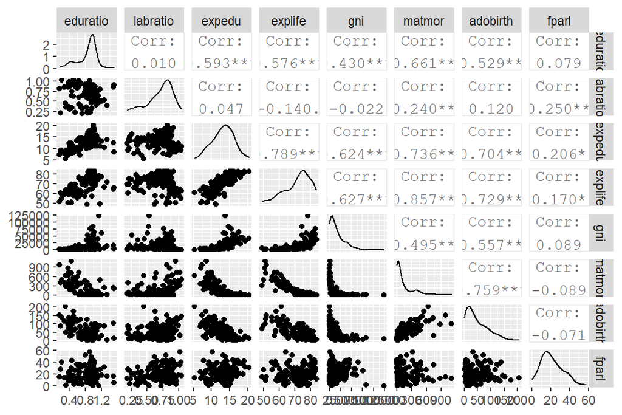

```r
human <- read.csv("data/human.csv", row.names = 1)
ggpairs(human)
```

The above matrix shows scatterplots, distributions, and correlations between variables. The distributions of some variables are quite skewed. Most notably, the gross national income per capita (gni) and maternal mortality (matmor) have mostly low value observations and few high value observations.

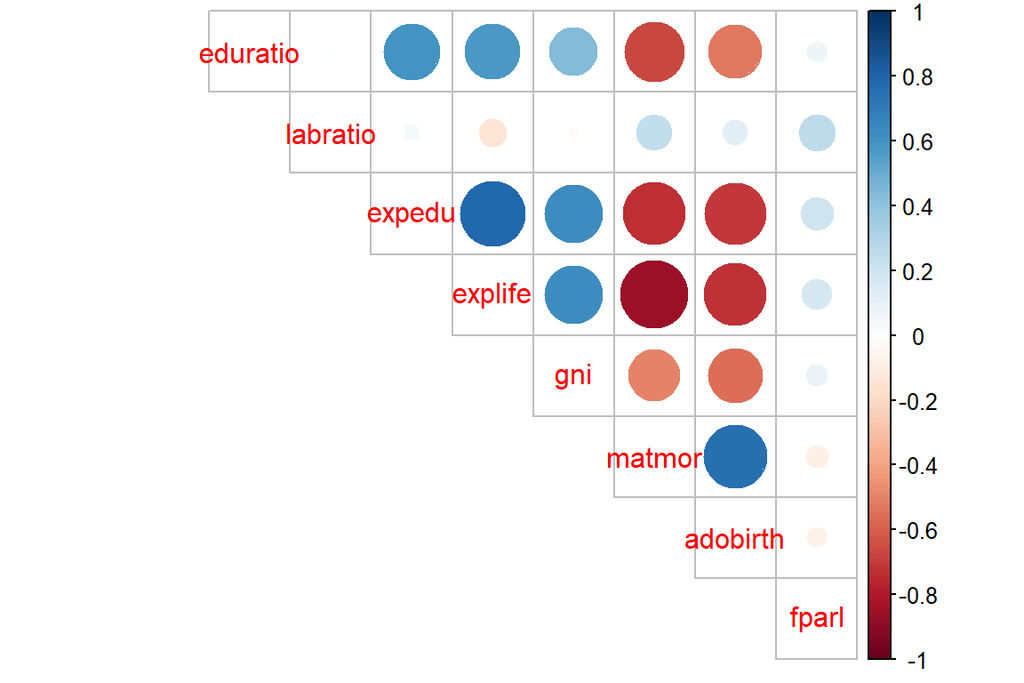

```r
corrplot(cor(human), method="circle", type = "upper", tl.pos = "d")
```

This correlation plot shows all correlations in a glance. The highest negative correlation is between maternal mortality and life expectancy at birth, while the highest positive correlation is between expected years of schooling and life expectancy at birth.

Here are also summaries of the variables:

```r
summary(human)
```

```
##     eduratio         labratio          expedu         explife
##  Min.   :0.1717   Min.   :0.1857   Min.   : 5.40   Min.   :49.00
##  1st Qu.:0.7264   1st Qu.:0.5984   1st Qu.:11.25   1st Qu.:66.30
##  Median :0.9375   Median :0.7535   Median :13.50   Median :74.20
##  Mean   :0.8529   Mean   :0.7074   Mean   :13.18   Mean   :71.65
##  3rd Qu.:0.9968   3rd Qu.:0.8535   3rd Qu.:15.20   3rd Qu.:77.25
##  Max.   :1.4967   Max.   :1.0380   Max.   :20.20   Max.   :83.50
##       gni             matmor          adobirth          fparl
##  Min.   :   581   Min.   :   1.0   Min.   :  0.60   Min.   : 0.00
##  1st Qu.:  4198   1st Qu.:  11.5   1st Qu.: 12.65   1st Qu.:12.40
##  Median : 12040   Median :  49.0   Median : 33.60   Median :19.30
##  Mean   : 17628   Mean   : 149.1   Mean   : 47.16   Mean   :20.91
##  3rd Qu.: 24512   3rd Qu.: 190.0   3rd Qu.: 71.95   3rd Qu.:27.95
##  Max.   :123124   Max.   :1100.0   Max.   :204.80   Max.   :57.50
```

## Principal component analysis

Next, I’ll perform the principal component analysis on the unstandardised data.

```r
pca_human <- prcomp(human)
summary(pca_human)
```

```
## Importance of components:
##                               PC1      PC2   PC3   PC4   PC5   PC6    PC7
## Standard deviation     18544.1639 185.5219 25.19 11.45 3.766 1.566 0.1912
## Proportion of Variance     0.9999   0.0001  0.00  0.00 0.000 0.000 0.0000
## Cumulative Proportion      0.9999   1.0000  1.00  1.00 1.000 1.000 1.0000
##                           PC8
## Standard deviation     0.1591
## Proportion of Variance 0.0000
## Cumulative Proportion  1.0000
```

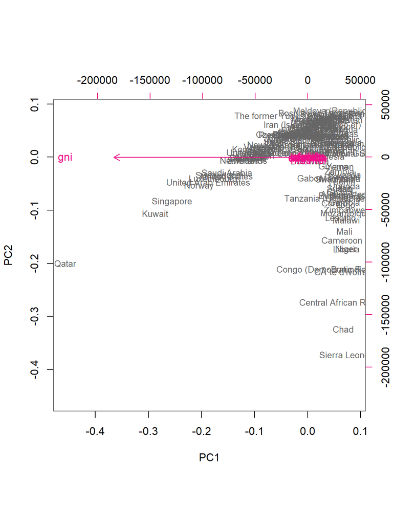

Figure 1. A biplot displaying variation captured by the first two principal components. The first component is mostly determined by gross national income per capita (gni) and it explains almost all of the variability

```r
biplot(pca_human, choices = 1:2, cex = c(0.8, 1), col = c("grey40", "deeppink2"))
```

The summary of the importance of components shows that the first component explains almost all of the variation. From the plot above (Figure 1) we can see that this component is mostly determined by GNI variable. This can be explained by that GNI has much larger range of values than the other variables, as seen in the summary. Therefore, it also has the largest variance. To identify the importance of different variables, we need to standardise the data.

```r
human_std <- scale(human)
summary(human_std)
```

```
##     eduratio          labratio           expedu           explife
##  Min.   :-2.8189   Min.   :-2.6247   Min.   :-2.7378   Min.   :-2.7188
##  1st Qu.:-0.5233   1st Qu.:-0.5484   1st Qu.:-0.6782   1st Qu.:-0.6425
##  Median : 0.3503   Median : 0.2316   Median : 0.1140   Median : 0.3056
##  Mean   : 0.0000   Mean   : 0.0000   Mean   : 0.0000   Mean   : 0.0000
##  3rd Qu.: 0.5958   3rd Qu.: 0.7350   3rd Qu.: 0.7126   3rd Qu.: 0.6717
##  Max.   : 2.6646   Max.   : 1.6632   Max.   : 2.4730   Max.   : 1.4218
##       gni              matmor           adobirth           fparl
##  Min.   :-0.9193   Min.   :-0.6992   Min.   :-1.1325   Min.   :-1.8203
##  1st Qu.:-0.7243   1st Qu.:-0.6496   1st Qu.:-0.8394   1st Qu.:-0.7409
##  Median :-0.3013   Median :-0.4726   Median :-0.3298   Median :-0.1403
##  Mean   : 0.0000   Mean   : 0.0000   Mean   : 0.0000   Mean   : 0.0000
##  3rd Qu.: 0.3712   3rd Qu.: 0.1932   3rd Qu.: 0.6030   3rd Qu.: 0.6127
##  Max.   : 5.6890   Max.   : 4.4899   Max.   : 3.8344   Max.   : 3.1850
```

Now we can see from the summary, that the data is standardised. All means are now 0.

```r
pca_human_std <- prcomp(human_std)
summary(pca_human_std)
```

```
## Importance of components:
##                           PC1    PC2     PC3     PC4     PC5     PC6     PC7
## Standard deviation     2.0708 1.1397 0.87505 0.77886 0.66196 0.53631 0.45900
## Proportion of Variance 0.5361 0.1624 0.09571 0.07583 0.05477 0.03595 0.02634
## Cumulative Proportion  0.5361 0.6984 0.79413 0.86996 0.92473 0.96069 0.98702
##                            PC8
## Standard deviation     0.32224
## Proportion of Variance 0.01298
## Cumulative Proportion  1.00000
```

Now the summary of the importance of components shows that the first component explains about 53.6% of the variation and the second component explains about 16.2%.

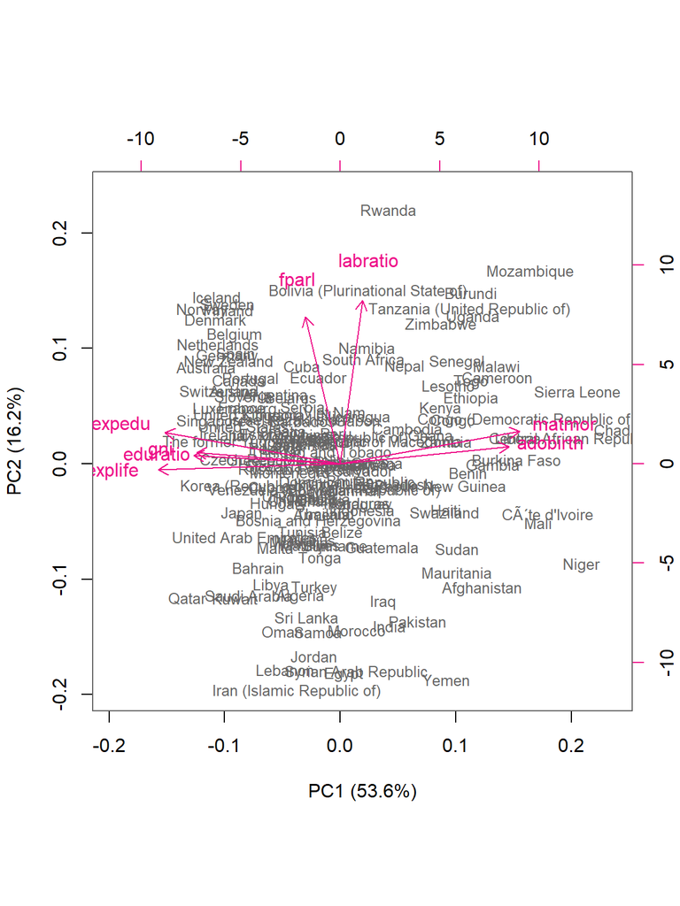

Figure 2. A biplot displaying variation captured by the first two principal components of the principal component analysis performed on the standardised data. The first component is determined by life expectancy, ratio of females to males with at least secondary education, gross national income per capita (gni), expected years of schooling, maternal mortality, and adolescent birth rate. The second component is determined by percetange of female representatives in parliament and ratio of females to males in the labour force.

```r
s <- summary(pca_human_std)
pca_pr <- round(100*s$importance[2, ], digits = 1)
pc_lab <- paste0(names(pca_pr), " (", pca_pr, "%)")
biplot(pca_human_std, choices = 1:2, cex = c(0.8, 1), col = c("grey40", "deeppink2"), xlab = pc_lab[1], ylab = pc_lab[2])
```

Here we can see how variables correlate with principal components and with each other (Figure 2). The angles between the arrows can be interpreted as correlations between the variables and the angles between arrows and principal component axes as correlations between them. The first principal component is defined by two sets of variables that correlate positively with each other but that are negatively correlated with the other set. One set includes life expectancy, ratio of females to males with at least secondary education, gross national income per capita (gni), and expected years of schooling. The other set includes maternal mortality and adolescent birth rate. The first principal component seems to catch variation mostly related to human development factors. The second principal component is defined by percetange of female representatives in parliament and ratio of females to males in the labour force, which correlate positively with each other. The second principal component seems to catch variation related to gender equality factors.

## Multiple correspondence analysis

Multiple correspondence analysis can be used to analyse qualitative data, such as categorical variables. I’ll run multiple correspondence analysis using tea data set from FactoMineR package.

```r
library(FactoMineR)
data(tea)
str(tea)
```

```
## 'data.frame':    300 obs. of  36 variables:
##  $ breakfast       : Factor w/ 2 levels "breakfast","Not.breakfast": 1 1 2 2 1 2 1 2 1 1 ...
##  $ tea.time        : Factor w/ 2 levels "Not.tea time",..: 1 1 2 1 1 1 2 2 2 1 ...
##  $ evening         : Factor w/ 2 levels "evening","Not.evening": 2 2 1 2 1 2 2 1 2 1 ...
##  $ lunch           : Factor w/ 2 levels "lunch","Not.lunch": 2 2 2 2 2 2 2 2 2 2 ...
##  $ dinner          : Factor w/ 2 levels "dinner","Not.dinner": 2 2 1 1 2 1 2 2 2 2 ...
##  $ always          : Factor w/ 2 levels "always","Not.always": 2 2 2 2 1 2 2 2 2 2 ...
##  $ home            : Factor w/ 2 levels "home","Not.home": 1 1 1 1 1 1 1 1 1 1 ...
##  $ work            : Factor w/ 2 levels "Not.work","work": 1 1 2 1 1 1 1 1 1 1 ...
##  $ tearoom         : Factor w/ 2 levels "Not.tearoom",..: 1 1 1 1 1 1 1 1 1 2 ...
##  $ friends         : Factor w/ 2 levels "friends","Not.friends": 2 2 1 2 2 2 1 2 2 2 ...
##  $ resto           : Factor w/ 2 levels "Not.resto","resto": 1 1 2 1 1 1 1 1 1 1 ...
##  $ pub             : Factor w/ 2 levels "Not.pub","pub": 1 1 1 1 1 1 1 1 1 1 ...
##  $ Tea             : Factor w/ 3 levels "black","Earl Grey",..: 1 1 2 2 2 2 2 1 2 1 ...
##  $ How             : Factor w/ 4 levels "alone","lemon",..: 1 3 1 1 1 1 1 3 3 1 ...
```

[output cut: 22 more lines]

```r
dim(tea)
```

```
## [1] 300  36
```

The data contains 300 observations of 36 variables. Other variable types are categorical, but age is an integer. Therefore, I’ll drop age from the analysis.

```r
tea <- tea %>% dplyr::select(-age)
```

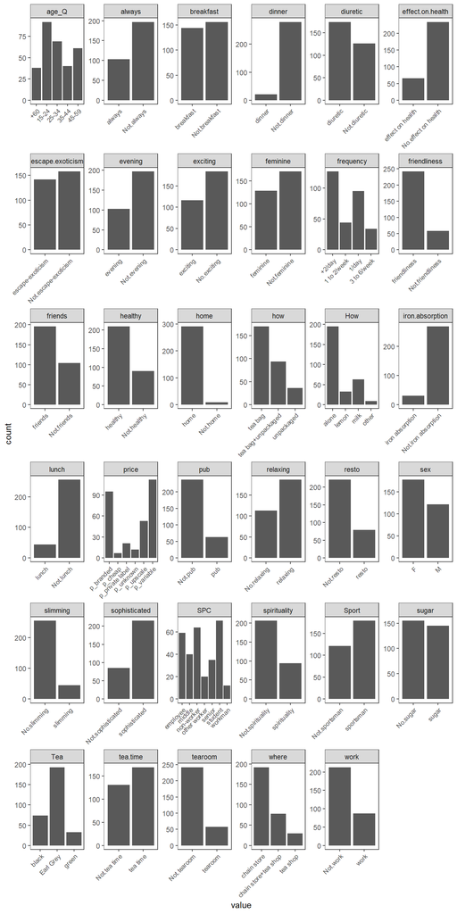

```r
gather(tea) %>% ggplot(aes(value)) +
        geom_bar() +
        theme_bw() +
        facet_wrap("key", scales = "free") +
        theme(
        panel.grid.major=element_blank(),
        panel.grid.minor=element_blank(),
        axis.text.x = element_text(angle = 45, hjust = 1, size = 8))
```

```r
mca <- MCA(tea, graph = FALSE)
summary(mca)
```

```
##
## Call:
## MCA(X = tea, graph = FALSE)
##
##
## Eigenvalues
##                        Dim.1   Dim.2   Dim.3   Dim.4   Dim.5   Dim.6   Dim.7
## Variance               0.090   0.082   0.070   0.063   0.056   0.053   0.050
## % of var.              5.838   5.292   4.551   4.057   3.616   3.465   3.272
## Cumulative % of var.   5.838  11.130  15.681  19.738  23.354  26.819  30.091
##                        Dim.8   Dim.9  Dim.10  Dim.11  Dim.12  Dim.13  Dim.14
## Variance               0.048   0.047   0.044   0.041   0.040   0.039   0.037
## % of var.              3.090   3.053   2.834   2.643   2.623   2.531   2.388
## Cumulative % of var.  33.181  36.234  39.068  41.711  44.334  46.865  49.252
##                       Dim.15  Dim.16  Dim.17  Dim.18  Dim.19  Dim.20  Dim.21
## Variance               0.036   0.035   0.034   0.032   0.031   0.031   0.030
## % of var.              2.302   2.275   2.172   2.085   2.013   2.011   1.915
## Cumulative % of var.  51.554  53.829  56.000  58.086  60.099  62.110  64.025
##                       Dim.22  Dim.23  Dim.24  Dim.25  Dim.26  Dim.27  Dim.28
## Variance               0.028   0.027   0.026   0.025   0.025   0.024   0.024
## % of var.              1.847   1.740   1.686   1.638   1.609   1.571   1.524
## Cumulative % of var.  65.872  67.611  69.297  70.935  72.544  74.115  75.639
##                       Dim.29  Dim.30  Dim.31  Dim.32  Dim.33  Dim.34  Dim.35
## Variance               0.023   0.022   0.021   0.020   0.020   0.019   0.019
## % of var.              1.459   1.425   1.378   1.322   1.281   1.241   1.222
## Cumulative % of var.  77.099  78.523  79.901  81.223  82.504  83.745  84.967
##                       Dim.36  Dim.37  Dim.38  Dim.39  Dim.40  Dim.41  Dim.42
## Variance               0.018   0.017   0.017   0.016   0.015   0.015   0.014
## % of var.              1.152   1.092   1.072   1.019   0.993   0.950   0.924
## Cumulative % of var.  86.119  87.211  88.283  89.301  90.294  91.244  92.169
##                       Dim.43  Dim.44  Dim.45  Dim.46  Dim.47  Dim.48  Dim.49
## Variance               0.014   0.013   0.012   0.011   0.011   0.010   0.010
## % of var.              0.891   0.833   0.792   0.729   0.716   0.666   0.660
## Cumulative % of var.  93.060  93.893  94.684  95.414  96.130  96.796  97.456
##                       Dim.50  Dim.51  Dim.52  Dim.53  Dim.54
## Variance               0.009   0.009   0.008   0.007   0.006
## % of var.              0.605   0.584   0.519   0.447   0.390
## Cumulative % of var.  98.060  98.644  99.163  99.610 100.000
##
## Individuals (the 10 first)
```

[output cut: 44 more lines]

```
## dinner         0.796  1.805  0.048  3.777 |
## Not.dinner    -0.060  0.136  0.048 -3.777 |
##
## Categorical variables (eta2)
##                 Dim.1 Dim.2 Dim.3
## breakfast     | 0.031 0.000 0.011 |
## tea.time      | 0.240 0.000 0.003 |
## evening       | 0.040 0.087 0.062 |
## lunch         | 0.062 0.029 0.010 |
## dinner        | 0.092 0.000 0.048 |
## always        | 0.056 0.035 0.007 |
## home          | 0.016 0.002 0.030 |
## work          | 0.075 0.020 0.022 |
## tearoom       | 0.321 0.019 0.031 |
## friends       | 0.186 0.061 0.030 |
```

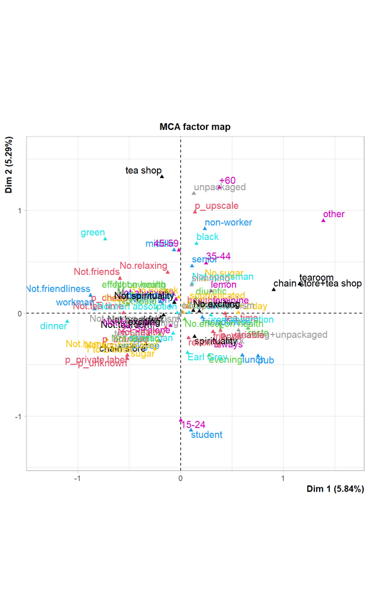

```r
plot(mca, invisible=c("ind"), habillage = "quali")
```

Multiple correspondence analysis with all variables looks quite messy and it’s difficult to interpret. I’ll concentrate on a few selected variables instead. I’ll choose Tea, How, evening, sugar, where, and lunch. Tea tells whether a person drinks Earl Grey, black tea, or green tea. How describes whether tea is drunk alone or with lemon, milk, or other. Evening describes whether tea is enjoyed in the evening or not and sugar whether a person drinks tea with or without sugar. Where includes information on whether tea is bought from a chain store, tea shop, or from both chain store and tea shop. Lunch describes whether or not tea is enjoyed at lunch.

```r
keep_columns <- c("Tea", "How", "evening", "sugar", "where", "lunch")
tea_time <- dplyr::select(tea, one_of(keep_columns))
```

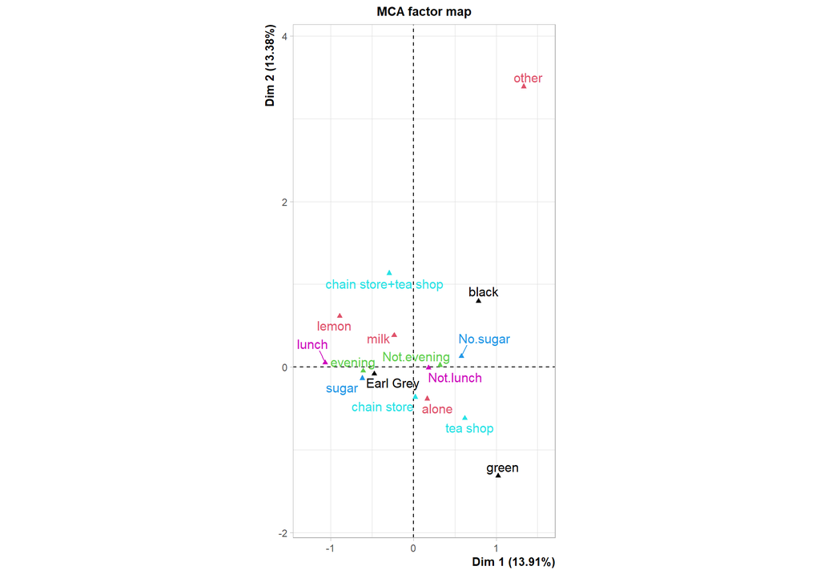

```r
mca <- MCA(tea_time, graph = FALSE)
plot(mca, invisible=c("ind"), habillage = "quali")
```

The different variables are depicted with different colours in the plot. Here we can see how different tea preferences are related to each other. The most notable thing we can see here is that furthest away from each other are the preference for green tea and to add something other than lemon or milk to the tea. The tightest cluster, on the other hand, seems to be preference for Earl Grey, sugar, and drinking tea in he evening.

# Analysis of longitudinal data

## Loading and inspecting the RATS data

I downloaded this data set from https://raw.githubusercontent.com/KimmoVehkalahti/MABS/master/Examples/data/rats.txt, and then wrangled it for longitudinal analysis purposes. The data is originally from a nutrition study comparing three groups of rats (Crowder and Hand, 1990).

```r
# Load the wrangled RATSL data
ratsl <- read.csv("data/RATSL.csv")

# Convert categorical variables to factors
ratsl$ID <- factor(ratsl$ID)
ratsl$Group <- factor(ratsl$Group)
```

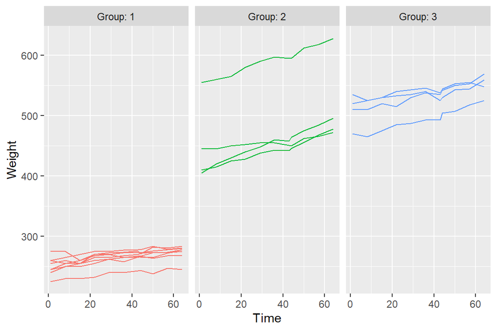

```r
ggplot(ratsl, aes(x = Time, y = Weight, Group = ID, col = Group)) +
  geom_line() +
  scale_linetype_manual(values = rep(1:10, times=4)) +
  facet_grid(. ~ Group, labeller = label_both) +
  theme(legend.position = "none") +
  scale_y_continuous(limits = c(min(ratsl$Weight), max(ratsl$Weight)))
```

The three groups of rats were on different diets. The rats were weighed approximately weekly. Their weights are depicted in the plot above. You can see that there were differences in their weights in the beginning of diets. Most notably the weight of all rats in group 1 was lower than in the two other groups. Also, it seems that in each group there is one rat whose weight differs from other rats in the same group. Also, you can see here that there were very few rats in each group. The rats who were heaviest in the beginning tend to have heavier weight through the diet, a phenomenon which is called tracking.

Next, I’ll standardise the data (subtract the measurement point mean from the observed values and divide by that measurement point’s standard deviation).

```r
ratsl <- ratsl %>%
  group_by(Time) %>%
  mutate(stdWeight = ((Weight-mean(Weight))/sd(Weight))) %>%
  ungroup()
```

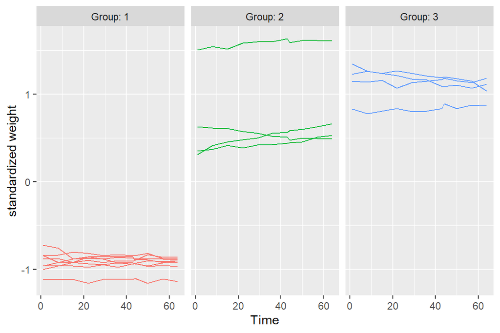

```r
ggplot(ratsl, aes(x = Time, y = stdWeight, Group = ID, col = Group)) +
  geom_line() +
  scale_linetype_manual(values = rep(1:10, times=4)) +
  facet_grid(. ~ Group, labeller = label_both) +
  theme(legend.position = "none") +
  scale_y_continuous(name = "standardized weight")
```

Above is the same kind of graph as before but this time with standardised values.

Next, I’ll create summary data and plot the means of each group at each measurement point with standard errors.

```r
# Number of days, baseline (day 1) included
n <- ratsl$Time %>% unique() %>% length()

# Summary data with mean and standard error of Weight by Group and Time
ratss <- ratsl %>%
  group_by(Group, Time) %>%
  summarise( mean = mean(Weight), se = sd(Weight)/sqrt(n) ) %>%
  ungroup()
glimpse(ratss)
```

```
## Rows: 33
## Columns: 4
## $ Group <fct> 1, 1, 1, 1, 1, 1, 1, 1, 1, 1, 1, 2, 2, 2, 2, 2, 2, 2, 2, 2, 2...
## $ Time  <int> 1, 8, 15, 22, 29, 36, 43, 44, 50, 57, 64, 1, 8, 15, 22, 29, 3...
## $ mean  <dbl> 250.625, 255.000, 254.375, 261.875, 264.625, 265.000, 267.375...
## $ se    <dbl> 4.589478, 3.947710, 3.460116, 4.100800, 3.333956, 3.552939, 3...
```

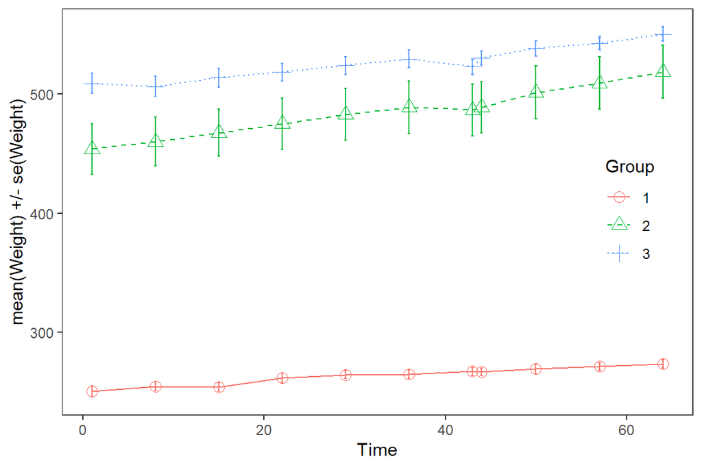

```r
# Plot the mean profiles
ggplot(ratss, aes(x = Time, y = mean, linetype = Group, shape = Group, col = Group)) +
  geom_line() +
  scale_linetype_manual(values = c(1,2,3)) +
  geom_point(size=3) +
  scale_shape_manual(values = c(1,2,3)) +
  geom_errorbar(aes(ymin=mean-se, ymax=mean+se, linetype="1"), width=0.3) +
  theme_bw() +
  theme(panel.grid.major = element_blank(), panel.grid.minor = element_blank()) +
  theme(legend.position = c(0.9,0.5)) +
  scale_y_continuous(name = "mean(Weight) +/- se(Weight)")
```

The mean weights seem to be increasing over time in all groups. The variability within group 1 is smaller than in the other groups. Group 2 has the largest variability.

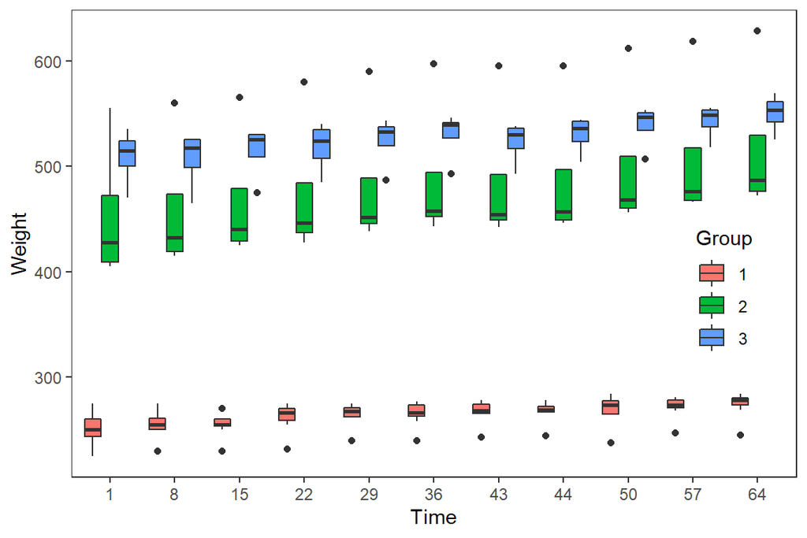

```r
ggplot(ratsl, aes(x = factor(Time), y = Weight, fill = Group)) +
  geom_boxplot(position = position_dodge(width = 0.8)) +
  theme_bw() +
  theme(panel.grid.major = element_blank(), panel.grid.minor = element_blank()) +
  theme(legend.position = c(0.9,0.4)) +
  scale_x_discrete(name = "Time")
```

Above is another way to plot the same data. This plot has side-by-side box plots of the group weights in each measurement point. In this plot the outliers can again be observed.

## Summary measure analysis

Summary measure method is simple, but it may be helpful in initial assessment on longitudinal data. I’ll create summary data of weights during the diet and excluding the starting weight.

```r
# Create summary data
rats_sum <- ratsl %>%
  filter(Time > 1) %>%
  group_by(Group, ID) %>%
  summarise( mean=mean(Weight) ) %>%
  ungroup()
```

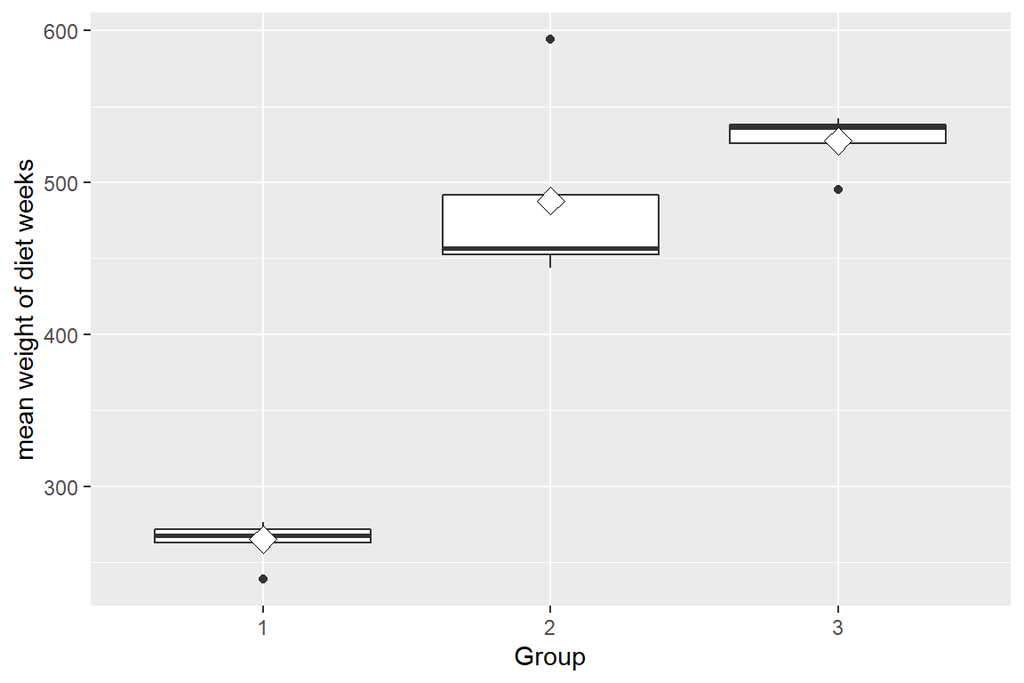

```r
ggplot(rats_sum, aes(x = Group, y = mean)) +
  geom_boxplot() +
  stat_summary(fun.y = "mean", geom = "point", shape=23, size=4, fill = "white") +
  scale_y_continuous(name = "mean weight of diet weeks")
```

Here are boxplots of mean weights of each group. There is one outlier in each group. I’ll remove the outliers from the data.

```r
# Remove the outliers
rats_no_out <- rats_sum %>%
  filter(ID != 2 & ID != 12 & ID != 13)
```

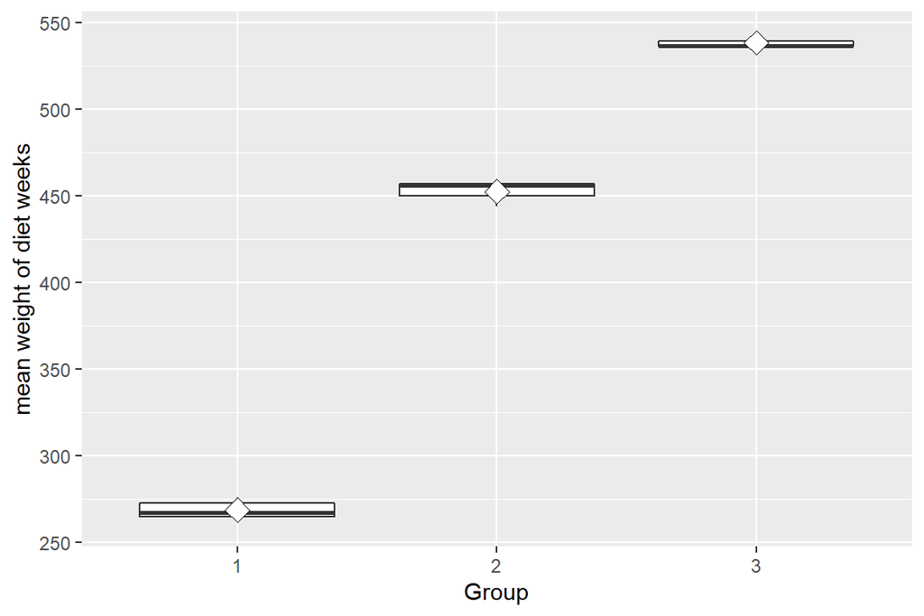

```r
ggplot(rats_no_out, aes(x = Group, y = mean)) +
  geom_boxplot() +
  stat_summary(fun.y = "mean", geom = "point", shape=23, size=4, fill = "white") +
  scale_y_continuous(name = "mean weight of diet weeks")
```

This is how the boxplots look without the outliers. Let’s compare the groups using ANOVA:

```r
# ANOVA of the data without outliers
summary(aov(mean ~ Group, data = rats_no_out))
```

```
##             Df Sum Sq Mean Sq F value             Pr(>F)
## Group        2 176917   88458    2836 0.0000000000000169 ***
## Residuals   10    312      31
## ---
## Signif. codes:  0 '***' 0.001 '**' 0.01 '*' 0.05 '.' 0.1 ' ' 1
```

The summary of ANOVA shows that the group weights differ significantly. However, the summary does not tell which groups differ from each other. I’ll perform Tukey test to find out:

```r
TukeyHSD(aov(mean ~ Group, data = rats_no_out))
```

```
##   Tukey multiple comparisons of means
##     95% family-wise confidence level
##
## Fit: aov(formula = mean ~ Group, data = rats_no_out)
##
## $Group
##          diff       lwr       upr p adj
## 2-1 183.64286 173.07885 194.20686     0
## 3-1 269.50952 258.94552 280.07353     0
## 3-2  85.86667  73.36717  98.36617     0
```

The Tukey test reveals that all groups differ from one another. None of the 95% confidence intervals includes zero. The biggest difference in weight is between groups 1 and 3.

The weight at the beginning of the diet is most likely correlated with the outcome measure of weight. Therefore, I’ll use the starting weight as the baseline covariate in the analysis:

```r
# Add the baseline from the original data
baseline <- ratsl %>% filter(Time==1) %>% rename(baseline = Weight) %>% filter(ID != 2 & ID != 12 & ID != 13)
rats_no_out2 <-rats_no_out %>% mutate(baseline)
```

```r
# ANCOVA of the data without outliers
summary(aov(mean ~ baseline + Group, data = rats_no_out2))
```

```
##             Df Sum Sq Mean Sq F value             Pr(>F)
## baseline     1 174926  174926 6630.94 0.0000000000000322 ***
## Group        2   2065    1033   39.15 0.0000362803291508 ***
## Residuals    9    237      26
## ---
## Signif. codes:  0 '***' 0.001 '**' 0.01 '*' 0.05 '.' 0.1 ' ' 1
```

Here we see that the baseline weight is strongly related to weight after diets have begun. Also, there are still differences between the groups after conditioning on the baseline weight.

## Loading and inspecting BPRS data

I downloaded this data set from https://raw.githubusercontent.com/KimmoVehkalahti/MABS/master/Examples/data/BPRS.txt, and then wrangled it for longitudinal analysis purposes. This data have psychiatric rating scale (BPRS) measurements from 40 male subjects in two treatment groups. I have converted the data to long format. Let’s glimpse the data and check how the 40 first rows look like:

```r
# Load the wrangled BPRSL data
bprsl <- read.csv("data/BPRSL.csv")

# Convert categorical variables to factors
bprsl$treatment <- factor(bprsl$treatment)
bprsl$subject <- factor(bprsl$subject)
bprsl$ID <- factor(bprsl$ID)
```

```r
glimpse(bprsl)
```

```
## Rows: 360
## Columns: 6
## $ treatment <fct> 1, 1, 1, 1, 1, 1, 1, 1, 1, 1, 1, 1, 1, 1, 1, 1, 1, 1, 1, ...
## $ subject   <fct> 1, 2, 3, 4, 5, 6, 7, 8, 9, 10, 11, 12, 13, 14, 15, 16, 17...
## $ ID        <fct> 1, 2, 3, 4, 5, 6, 7, 8, 9, 10, 11, 12, 13, 14, 15, 16, 17...
## $ weeks     <chr> "week0", "week0", "week0", "week0", "week0", "week0", "we...
## $ bprs      <int> 42, 58, 54, 55, 72, 48, 71, 30, 41, 57, 30, 55, 36, 38, 6...
## $ week      <int> 0, 0, 0, 0, 0, 0, 0, 0, 0, 0, 0, 0, 0, 0, 0, 0, 0, 0, 0, ...
```

```r
head(bprsl, n = 40)
```

```
##    treatment subject ID weeks bprs week
## 1          1       1  1 week0   42    0
## 2          1       2  2 week0   58    0
## 3          1       3  3 week0   54    0
## 4          1       4  4 week0   55    0
## 5          1       5  5 week0   72    0
## 6          1       6  6 week0   48    0
## 7          1       7  7 week0   71    0
## 8          1       8  8 week0   30    0
## 9          1       9  9 week0   41    0
## 10         1      10 10 week0   57    0
## 11         1      11 11 week0   30    0
## 12         1      12 12 week0   55    0
## 13         1      13 13 week0   36    0
## 14         1      14 14 week0   38    0
```

[output cut: 26 more lines]

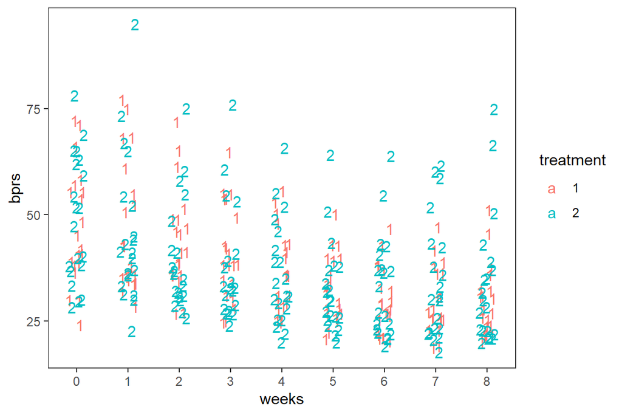

```r
ggplot(bprsl, aes(x = week, y = bprs, group = ID, col = treatment)) +
  geom_text(position = position_jitter(width = 0.15), aes(label = treatment)) +
  scale_x_continuous(name = "weeks", breaks = seq(0, 8, 1)) +
  scale_y_continuous(name = "bprs") +
  theme_bw() +
  theme(panel.grid.major = element_blank(), panel.grid.minor = element_blank())
```

The plot above shows the bprs scores of subjects belonging to the two groups each measurement week. The two groups do not seem to differ from each other very clearly.

## Fitting linear mixed model to the data

I’ll fit a multiple linear regression model with bprs as response and week and treatment as explanatory variables.

```r
bprs_reg <- lm(bprs ~ week + treatment, data = bprsl)
summary(bprs_reg)
```

```
##
## Call:
## lm(formula = bprs ~ week + treatment, data = bprsl)
##
## Residuals:
##     Min      1Q  Median      3Q     Max
## -22.454  -8.965  -3.196   7.002  50.244
##
## Coefficients:
##             Estimate Std. Error t value            Pr(>|t|)
## (Intercept)  46.4539     1.3670  33.982 <0.0000000000000002 ***
## week         -2.2704     0.2524  -8.995 <0.0000000000000002 ***
## treatment2    0.5722     1.3034   0.439               0.661
## ---
## Signif. codes:  0 '***' 0.001 '**' 0.01 '*' 0.05 '.' 0.1 ' ' 1
##
## Residual standard error: 12.37 on 357 degrees of freedom
## Multiple R-squared:  0.1851, Adjusted R-squared:  0.1806
## F-statistic: 40.55 on 2 and 357 DF,  p-value: < 0.00000000000000022
```

There seems to be a significant effect of measurement week. The bprs scores get lower during the treatment. However, the treatment group does not seem to have a significant effect.

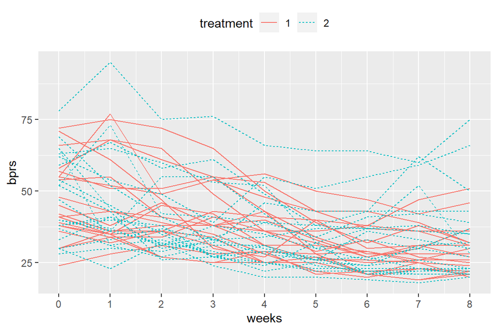

```r
ggplot(bprsl, aes(x = week, y = bprs, group = ID, linetype = treatment)) +
  geom_line(aes(col = treatment)) +
  scale_x_continuous(name = "weeks", breaks = seq(0, 8, 1)) +
  scale_y_continuous(name = "bprs") +
  theme(legend.position = "top")
```

In the plot above you can see how the bprs score changes over time in the individual subjects.

Next, I’ll fit a random intercept model which allows each subject’s intercept to differ from other subjects.

```r
bprs_ref <- lmer(bprs ~ week + treatment + (1 | ID), data = bprsl, REML = FALSE)
summary(bprs_ref)
```

```
## Linear mixed model fit by maximum likelihood  ['lmerMod']
## Formula: bprs ~ week + treatment + (1 | ID)
##    Data: bprsl
##
##      AIC      BIC   logLik deviance df.resid
##   2582.9   2602.3  -1286.5   2572.9      355
##
## Scaled residuals:
##      Min       1Q   Median       3Q      Max
## -2.27506 -0.59909 -0.06104  0.44226  3.15835
##
## Random effects:
##  Groups   Name        Variance Std.Dev.
##  ID       (Intercept) 97.39    9.869
##  Residual             54.23    7.364
## Number of obs: 360, groups:  ID, 40
##
## Fixed effects:
##             Estimate Std. Error t value
## (Intercept)  46.4539     2.3521  19.750
## week         -2.2704     0.1503 -15.104
## treatment2    0.5722     3.2159   0.178
##
## Correlation of Fixed Effects:
##            (Intr) week
## week       -0.256
## treatment2 -0.684  0.000
```

The results remain mostly similar to the results of multiple linear regression model. The t-value of week is high, indicating that tere is an effect of time. The t-value of treatment is low suggesting that no effect of the treatment is found.

Then I’ll fit a random intercept and random slope model, which allows for each subject to differ both in the intercept and the slope.

```r
# create a random intercept and random slope model
bprs_ref1 <- lmer(bprs ~ week + treatment + (week | ID), data = bprsl, REML = FALSE)
summary(bprs_ref1)
```

```
## Linear mixed model fit by maximum likelihood  ['lmerMod']
## Formula: bprs ~ week + treatment + (week | ID)
##    Data: bprsl
##
##      AIC      BIC   logLik deviance df.resid
##   2523.2   2550.4  -1254.6   2509.2      353
##
## Scaled residuals:
##     Min      1Q  Median      3Q     Max
## -2.4655 -0.5150 -0.0920  0.4347  3.7353
##
## Random effects:
##  Groups   Name        Variance Std.Dev. Corr
##  ID       (Intercept) 167.827  12.955
##           week          2.331   1.527   -0.67
##  Residual              36.747   6.062
## Number of obs: 360, groups:  ID, 40
##
## Fixed effects:
##             Estimate Std. Error t value
## (Intercept)  45.9830     2.6470  17.372
## week         -2.2704     0.2713  -8.370
## treatment2    1.5139     3.1392   0.482
##
## Correlation of Fixed Effects:
##            (Intr) week
## week       -0.545
## treatment2 -0.593  0.000
```

And again, the results stay similar to the previous ones. We can compare the two models with ANOVA:

```r
# perform an ANOVA test on the two models
anova(bprs_ref1, bprs_ref)
```

```
## Data: bprsl
## Models:
## bprs_ref: bprs ~ week + treatment + (1 | ID)
## bprs_ref1: bprs ~ week + treatment + (week | ID)
##           npar    AIC    BIC  logLik deviance  Chisq Df          Pr(>Chisq)
## bprs_ref     5 2582.9 2602.3 -1286.5   2572.9
## bprs_ref1    7 2523.2 2550.4 -1254.6   2509.2 63.663  2 0.00000000000001499 ***
## ---
## Signif. codes:  0 '***' 0.001 '**' 0.01 '*' 0.05 '.' 0.1 ' ' 1
```

The ANOVA test shows a likelihood ratio test between the two models. The fit of the models differs significantly. The random intercept and random slope model has a better fit.

Let’s try to improve the model further by allowing for a treatment x time interaction.

```r
bprs_ref2 <- lmer(bprs ~ week * treatment + (week | ID), data = bprsl, REML = FALSE)
summary(bprs_ref2)
```

```
## Linear mixed model fit by maximum likelihood  ['lmerMod']
## Formula: bprs ~ week * treatment + (week | ID)
##    Data: bprsl
##
##      AIC      BIC   logLik deviance df.resid
##   2523.5   2554.5  -1253.7   2507.5      352
##
## Scaled residuals:
##     Min      1Q  Median      3Q     Max
## -2.4747 -0.5256 -0.0866  0.4435  3.7884
##
## Random effects:
##  Groups   Name        Variance Std.Dev. Corr
##  ID       (Intercept) 164.204  12.814
##           week          2.203   1.484   -0.66
##  Residual              36.748   6.062
## Number of obs: 360, groups:  ID, 40
##
## Fixed effects:
##                 Estimate Std. Error t value
## (Intercept)      47.8856     2.9840  16.047
## week             -2.6283     0.3752  -7.006
## treatment2       -2.2911     4.2200  -0.543
## week:treatment2   0.7158     0.5306   1.349
##
## Correlation of Fixed Effects:
##             (Intr) week   trtmn2
## week        -0.668
## treatment2  -0.707  0.473
## wek:trtmnt2  0.473 -0.707 -0.668
```

And then compare this model to the previous one:

```r
anova(bprs_ref2, bprs_ref1)
```

```
## Data: bprsl
## Models:
## bprs_ref1: bprs ~ week + treatment + (week | ID)
## bprs_ref2: bprs ~ week * treatment + (week | ID)
##           npar    AIC    BIC  logLik deviance Chisq Df Pr(>Chisq)
## bprs_ref1    7 2523.2 2550.4 -1254.6   2509.2
## bprs_ref2    8 2523.5 2554.6 -1253.7   2507.5  1.78  1     0.1821
```

The model with interaction does not fit the data better than the model without interaction.

Finally, I’ll plot the observed values side by side with the fitted values from the model with the best fit.

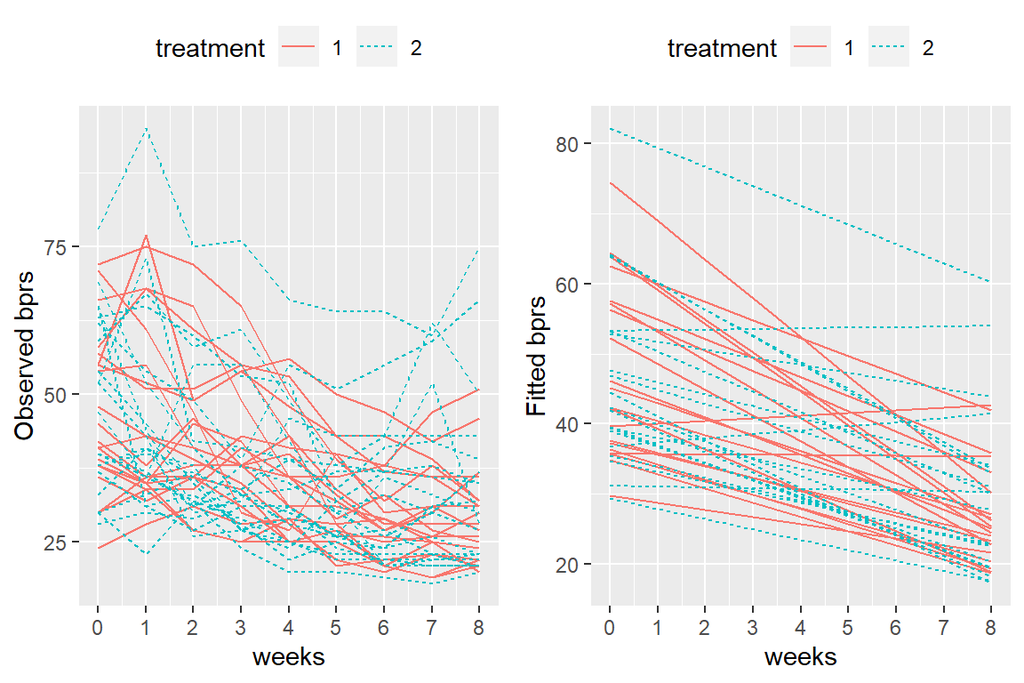

```r
# Create a vector of the fitted values
fitted <- fitted(bprs_ref1)

# Create a new column fitted to bprsl
bprsl <- bprsl %>% mutate(fitted)

# draw the plot of bprsl observed values
graph1 <- ggplot(bprsl, aes(x = week, y = bprs, group = ID, linetype = treatment)) +
  geom_line(aes(col = treatment)) +
  scale_x_continuous(name = "weeks", breaks = seq(0, 8, 1)) +
  scale_y_continuous(name = "Observed bprs") +
  theme(legend.position = "top")

# draw the plot of bprsl fitted values
graph2 <- ggplot(bprsl, aes(x = week, y = fitted, group = ID, linetype = treatment)) +
  geom_line(aes(col = treatment)) +
  scale_x_continuous(name = "weeks", breaks = seq(0, 8, 1)) +
  scale_y_continuous(name = "Fitted bprs") +
  theme(legend.position = "top")

grid.arrange(graph1, graph2, ncol = 2)
```

From the plot above we can see that the fitted values show the general tendency of bprs scores getting lower as the treatments go on.